# Agresti (20xx) Chapter 1

October 1, 2014

## Background

- If you've had a course in statistical theory, this chapter is likely *entirely* review.
- Categorical variable: measurement scale consisting of a set of categories.
- Research studies in the social and biomedical science drove the development of categorical data analysis (CDA).
- Applications in a myriad fields - behavioral sciences, education, engineering, ecology, public health, advertising, etc.

## Nominal scales

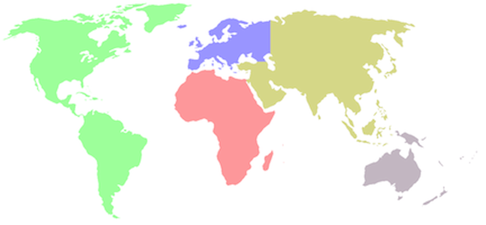

[figure not shown]

## Ordinal scales

[figure not shown]

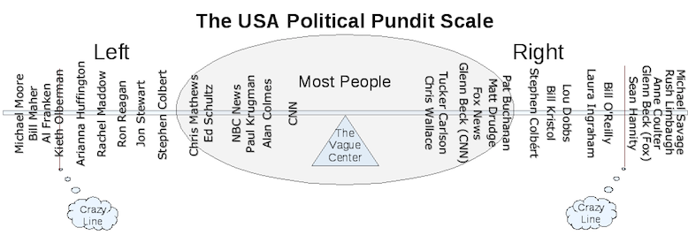

## Interval scale

- Natural order
- Distance between categories known.
- The way a variable is measured affects its classification.
- Interval > Ordinal > Nominal Hierarchy
- Methods for ordinal data **can** be applied to interval data but **not** the other way around.
- Usually best to use methods developed for a particular scale.

## Other variable distinctions

- Continuous vs. discrete variables
- Many vs. few categories
- Qualitative vs. Quantitative variables.
- Quality vs. quantity

## Binomial distribution

- Number of days late to class in a week.
- Let \(y_1, y_2, ..., y_n\) be realizations of \(Y_1, Y_2, Y_n\) that are i.i.d. with a fixed number, *n*, of binary observations.
- Then \(P(Y_i = 1) = p\) (success) and \(P(Y_i = 0) = 1 - p\) (failure).
- Late ("success") and ontime ("failure")
- Each realization is a Bernoulli trial, where the total number of successes, \(Y = \sum_{i = 1}^n Y_i\) is distributed with a Bin(n, p).

## Binomial (continued)

\[ Pr(y) = \binom{n}{y}p^y (1 - p)^{n - y} \]

- \(E(Y_i) = p\) and \(E(\sum_{i = 1}^n Y_i) = np\)
- \(var(Y_i) = p(1 - p) = pq\) and \(var(\sum_{i = 1}^n Y_i) = np(1 - p) = npq\).
- Maxium variability when \(p\) = 0.50
- For a fixed *p*, as \(n \rightarrow \infty\), Binomial \(\rightarrow\) normal
- Hypergeometric appropriate when binary observations are not i.i.d.
- Often model \(p\) with covariates and a binomial logistic regression

## Multinomial distribution

- *n* realizations with an outcome with *C* categories (C = 2 special case).
- Let \(y_{ij}\) = 1 if type *i* has outcome in category *j*, else \(y_{ij}\) = 0.
- If \(\mathbf{y_i} = (y_{i1}, y_{i2}, .., y_{ic})\) (\(y_{ic}\) is linearly dependent on the other outcomes).
- Let \(n_j = \sum_{i}y_{ij}\), then \((n_1, n_2, ..., n_c) \sim Multi(n, p_1, p_2, ..., p_c)\)

## Multinomial (continued)

\[Pr(n_1, n_2, ..., n_{c-1}) = \frac{n!}{n_1!n_2! \cdots n_c!}p_1^{n_1}p_2^{n_2}\cdots p_c^{n_c} \]

- \(E(n_j) = np_j\)
- \(var(n_j) = np_j(1 - p_j)\)
- \(cov(n_j, n_k) = -np_jp_k\)
- Marginal distributions of \(n_j\) are binomial.
- When C = 2, the binomial is a special case.

## Poisson

- Unbounded, non-negative counts. \[Pr(y) = \frac{e^{-\lambda}\lambda^y}{y!}\] for *y* = 0, 1, 2, …
- \(E(y) = var(y) = \lambda\).
- As \(\lambda \rightarrow \infty\), Poisson \(\rightarrow\) normal.
- Approximation of the binomial when \(n\) is large and \(p\) is small (\(\lambda = np\)).
- The sum of Poissons is also distributed with a Poisson and if we condition on *n* then this has a Multinomial distribution.

## Problems with these distributions

- Overdispersion, \(D = var(Y)/E(Y)\)
- For Poission, may need negative binomial (a Gamma mixture of Poisson distributions).
- Models are too simplistic or misspecified.

## Parameter estimation, MLE

- Typically use MLE (could use Bayes, of course)
- They have large-sample normal distributions
  - they are asymptotically consistent
  - converging to the parameter as n increases;
  - are asymptotically efficient, producing large-sample standard errors no greater than those from other estimation methods.
- MLE of \(\hat{\beta} = \frac{dL(\beta)}{d\beta} = 0\) and SEs are the square roots of the diagonal elements of the inverse information matrix.

## MLE Bernoulli

\[ pmf : Pr(y) = \binom{n}{y}p^y (1 - p)^{n - y} \] \[ L(p) = p^y (1 - p)^{n - y} \] \[ \log L(p) = y\log p + (n - y) \log(1-p) \] \[ \frac{d \log L(p)}{d p} = \frac{y}{p} - \frac{n - y}{1 - p}\] \[ \frac{d \log L(p)}{d p} = \frac{y - yp - np - yp}{p (1 - p)}\] \[ 0 = \frac{y - np}{p (1 - p)} \rightarrow y - np = 0 \rightarrow p = y/n\]

## Wald, LRT, and score tests

- Wald : z = \((\hat{\beta} - \beta_0)/SE\)
- LRT: -2 \(\log(l_0/l_1)\), where \(l_0\) max. value logLik fx under \(H_0\) restriction and max. logLik fx \(l_1\) without restriction of \(H_0\).
- Score: Based on slope and expected curvature of logLik fx at \(\beta_0\).
- \(u(\beta) = dL/d\beta\) at \(\beta_0\), typically large when \(\hat{\beta}\) away from \(\beta_0\).
- Score = \(u(\beta)/\sqrt{i(\beta_0)}\)
- Wald and Score follow a Z and LRT follows a \(\chi^2\)

## Plot of logLik fx

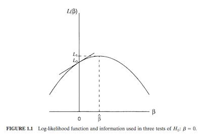

- Wald uses L(\(\beta\)) behavior at MLE for SE (nonnull)
- Score uses L(\(\beta\)) behavior at H\(_O\) for SE (null)
- LRT uses information at both and is twice the vertical distance from \(\beta\) to \(\beta_0\).
- Can of course construct CIs.

## Comparsions

- All three methods are likelihood based
- The Wald test uses the NONNULL standard error
- The Score test uses the NULL standard error (information evaluated at the null)
- The likelihood ratio test combines information from the null and observed likelihoods
- For small to medium samples, the likelihood ratio test is better
- I've been taught to only consider the LRT

## Single parameter tests

- Agresti derives hyptothesis tests/CIs for binomial parameter for Wald, score, and LRT and then multinomial parameters.
- Show poor performance of Wald confidence intervals when parameter lies on the boundary of the sample space (asks a class "who is vegetarian?", 0 yes, 26 no).
- Better performance of score and LRT.
- When \(n\) is small recommends the Clopper-Pearson method for CIs.
- Clopper-Pearson method for confidence interval uses \(P\)-values from a binomial exact test.
- Actual coverage always greater than .95

## Performance

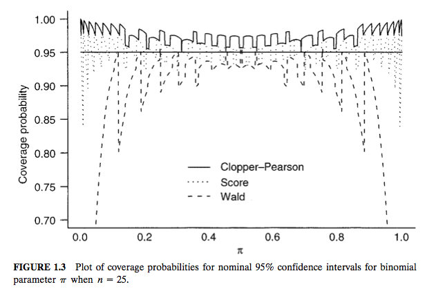

## Clopper-Pearson with mid-\(P\)-value

- mid-*P*-value = \(1/2 Pr(T = t\_0) + P(T > t\_0)\)
- Thus mid-*P*-value is less than the ordinary *P*-value by half the probability of the observed result.

## Multinomial

- Pearson's chi-squared statistic, X\(^2\) - \(\sum\frac{(obs-exp)^2}{exp}\) with df = c - 1
- LRT chi-squared statistic, G\(^2\) - \(2 \sum n_j log(n_j/np_{j0})\), for large *n*, df = c - 1.
- Mendel's data
- Chi-squared approximation of G\(^2\) poor when \(n / c < 5\) and fine for X\(^2\) when c is large and \(n/c\) is as small as 1 if exp freq aren't too big or too small.

## Simple example in `R`

```r
set.seed(123)
y <- rbinom(10, size = 1, prob = .3)
success <- sum(y[y==1])
prop.test(success, n = 10, correct = FALSE)  ## pseudo-Wald
```

```
##
##  1-sample proportions test without continuity correction
##
## data:  success out of 10, null probability 0.5
## X-squared = 0.4, df = 1, p-value = 0.5271
## alternative hypothesis: true p is not equal to 0.5
## 95 percent confidence interval:
##  0.1681803 0.6873262
## sample estimates:
##   p
## 0.4
```

## Simple example in `R`

```r
binom.test(success, n = 10)  ## Clopper & Pearson
```

```
##
##  Exact binomial test
##
## data:  success and 10
## number of successes = 4, number of trials = 10, p-value = 0.7539
## alternative hypothesis: true probability of success is not equal to 0.5
## 95 percent confidence interval:
##  0.1215523 0.7376219
## sample estimates:
## probability of success
##                    0.4
```

## `R` when y is on the sample space

```r
y <- rep(1, 10)
success <- sum(y[y==1])
prop.test(success, n = 10, correct = FALSE)  ## pseudo-Wald
```

```
##
##  1-sample proportions test without continuity correction
##
## data:  success out of 10, null probability 0.5
## X-squared = 10, df = 1, p-value = 0.001565
## alternative hypothesis: true p is not equal to 0.5
## 95 percent confidence interval:
##  0.7224672 1.0000000
## sample estimates:
## p
## 1
```

## `R` when y is on the sample space

```r
binom.test(success, n = 10)  ## Clopper & Pearson
```

```
##
##  Exact binomial test
##
## data:  success and 10
## number of successes = 10, number of trials = 10, p-value =
## 0.001953
## alternative hypothesis: true probability of success is not equal to 0.5
## 95 percent confidence interval:
##  0.6915029 1.0000000
## sample estimates:
## probability of success
##                      1
```

## `R` Pearson's chi-squared test

```r
x <- c(A = 16, B = 15, C = 17)
chisq.test(x)  # Ho = p1 = p2 = p3
```

```
##
##  Chi-squared test for given probabilities
##
## data:  x
## X-squared = 0.125, df = 2, p-value = 0.9394
```

## `R` Another Pearson's chi-squared test

```r
x <- c(A = 40, B = 20, C = 10)
chisq.test(x)
```

```
##
##  Chi-squared test for given probabilities
##
## data:  x
## X-squared = 20, df = 2, p-value = 4.54e-05
```